# Analyse von Trinkbrunnen in Deutschland auf Open Street Maps (OSM)

Enrico Lauckner (hamburg@correlaid.org / bremen@correlaid.org)

11/20/2022

## Lizenz

Daten sind von [OpenStreetMap (OSM)](https://www.openstreetmap.org/) und stehen unter der [Open Data Commons Open Database License (ODbL)](https://opendatacommons.org/licenses/odbl/). Details [hier](https://www.openstreetmap.org/copyright).

## Zusammenfassung

- fountains_osm: Eingetragene Trinkbrunnen in OSM
- fountains_per_1000: Eingetragene Trinkbrunnen in OSM pro 1.000 Einwohner
- fountains_official: Offiziele Anzahl Trinbrunnen (manuell von tiptap bei ausgewählten Städten abgefragt)
- official_vs_osm: Eingetragene Trinkbrunnen in OSM minus offiziele Anzahl Trinbrunnen
- mean_quality: Durchschnittliche Qualität der Metadaten (Erklärung siehe unten)

```
##                 city population fountains_osm official_vs_osm fountains_per_1000 fountains_official mean_quality
## 1             Berlin    3677472           220              48               0.06                172        0.529
## 2            Hamburg    1853935            89              NA               0.05                 NA        0.164
## 3            München    1487708            52              NA               0.03                 NA        0.218
## 4               Köln    1073096            61              48               0.06                 13        0.115
## 5  Frankfurt am Main     759224            52              39               0.07                 13        0.237
## 6          Stuttgart     626275            62             -21               0.10                 83        0.210
## 7         Düsseldorf     619477            68              57               0.11                 11        0.098
## 8            Leipzig     601866            18               3               0.03                 15        0.333
## 9           Dortmund     586852            33              NA               0.06                 NA        0.131
## 10             Essen     579432             6              NA               0.01                 NA        0.612
```

## Trinkbrunnen OSM

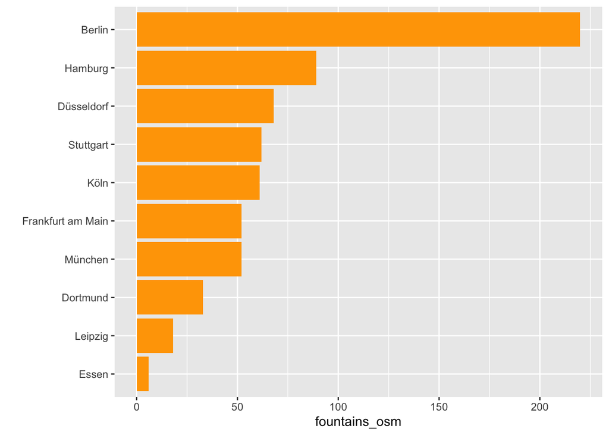

## Offiziell vs OSM

In den meisten Städten sind in OSM mehr Trinkbrunnen eingetragen als offiziell angegeben. Ausnahme Stuttgart, hier scheinen noch viele Brunnen in OSM zu fehlen.

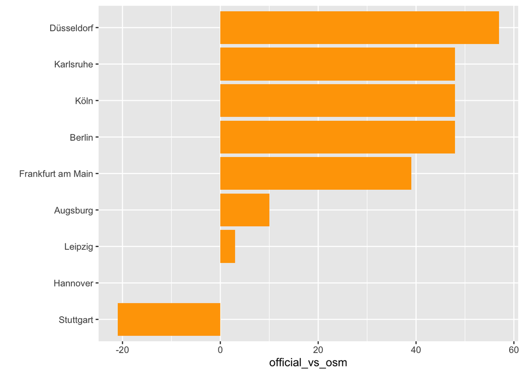

## Trinkbrunnen OSM pro 1.000 Einwohner

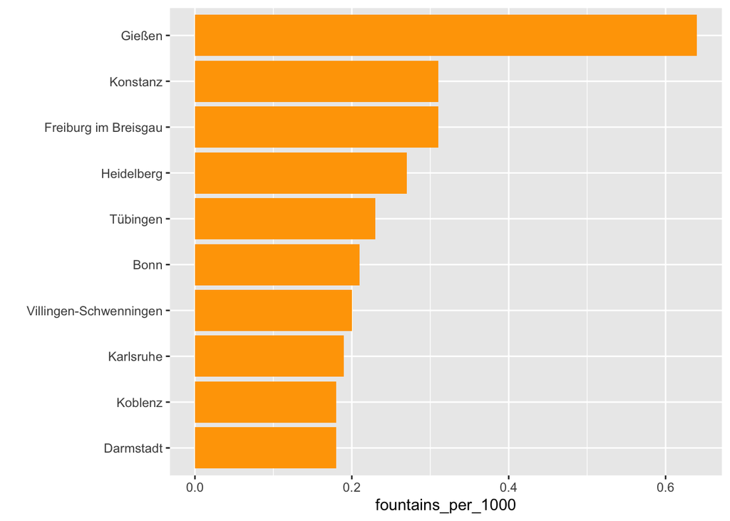

## Qualität Metadaten OSM

Leider sind die Metadaten/Tags sehr schlecht gepflegt, selbst das bestgefüllte Tag `wheelchair` fehlt bei fast 75% aller Nodes

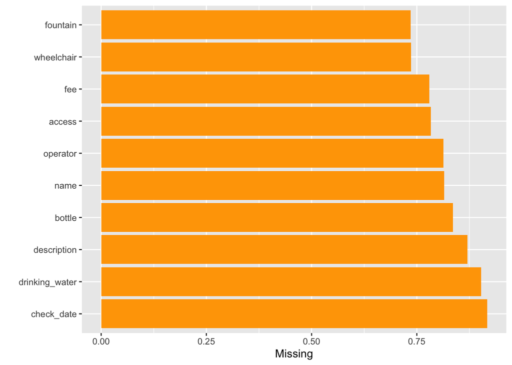

Aufgrund fehlender Daten wird die Qualität eines Punktes nur mit den folgenden Tags bestimmt:

- wheelchair

  ```
  ##      Var1 Freq
  ## 1     yes  279
  ## 2 limited  104
  ## 3      no   34
  ## 4     bad    1
  ```

- bottle

  ```
  ##   Var1 Freq
  ## 1  yes  244
  ## 2   no   16
  ```

- access

  ```
  ##         Var1 Freq
  ## 1        yes  304
  ## 2  customers   19
  ## 3    private   16
  ## 4 permissive    3
  ## 5         no    1
  ```

Für jedes vorhandene Tag wird ein Punkt vergeben, diese summiert und durch die Anzahl der vewendeten Tags geteilt. Daraus ergeben sich 100% wenn alle Tags gefüllt sind, 66% wenn 2/3 Tags gefüllt sind usw. Daraus ergbit sich folgendes Ranking:

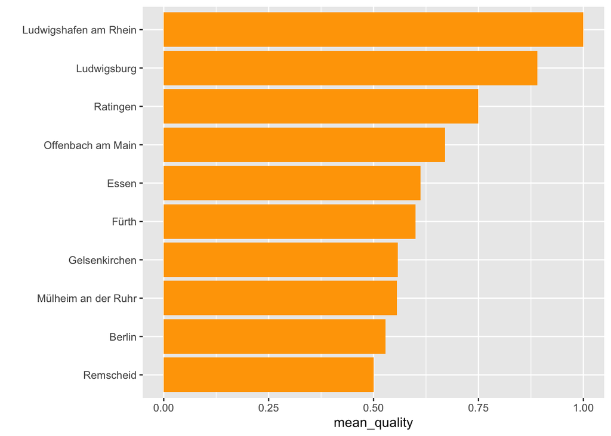

## Anzahl Trinkbrunnen vs Qualität

Die meisten Städte befinden sich im schlechtesten Quadranten links unten (wenig eingetragene Trinkbrunnen relativ zur Einwohnerzahl, schlechte Qualität). Der beste Quadrant rechts oben (viele Trinkbrunnen, hohe Qualität der Metadaten) ist leider komplett leer

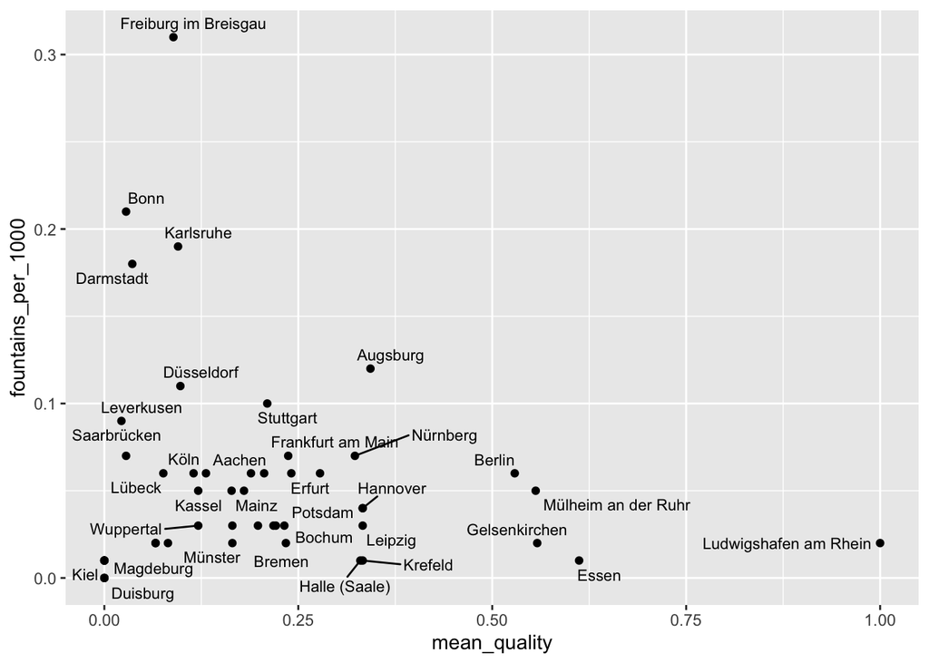